# Re_Cell

```python
# Libraries to help with reading and manipulating data
import numpy as np
import pandas as pd

# Libraries to help with data visualization
import matplotlib.pyplot as plt
import seaborn as sns

sns.set()

# split the data into train and test
from sklearn.model_selection import train_test_split

# to build linear regression_model
from sklearn.linear_model import LinearRegression

# to check model performance
from sklearn.metrics import mean_absolute_error, mean_squared_error, r2_score

# to build linear regression_model using statsmodels
import statsmodels.api as sm

# to compute VIF
from statsmodels.stats.outliers_influence import variance_inflation_factor
```

```python
import os

# Troubleshooting: Print current directory and files in it
print(f"Current Working Directory: {os.getcwd()}")
print(f"Files in this folder: {os.listdir('.')}")
```

```
Current Working Directory: /Users/clementquagraine/ReCell_project
Files in this folder: ['Re_Cell.ipynb', '.ipynb_checkpoints']
```

```python
import os
print("Your Notebook is running in:", os.getcwd())
print("\nFiles Jupyter can see in this folder:")
print(os.listdir())
```

```
Your Notebook is running in: /Users/clementquagraine/ReCell_project

Files Jupyter can see in this folder:
['Re_Cell.ipynb', '.ipynb_checkpoints']
```

```python
df = pd.read_csv('/Users/ClementQuagraine/Downloads/used_device_data.csv')
```

```python
df.head()
```

|  | brand_name | os | screen_size | 4g | 5g | main_camera_mp | selfie_camera_mp | int_memory | ram | battery | weight | release_year | days_used | normalized_used_price | normalized_new_price |
| --- | --- | --- | --- | --- | --- | --- | --- | --- | --- | --- | --- | --- | --- | --- | --- |
| 0 | Honor | Android | 14.50 | yes | no | 13.0 | 5.0 | 64.0 | 3.0 | 3020.0 | 146.0 | 2020 | 127 | 4.307572 | 4.715100 |
| 1 | Honor | Android | 17.30 | yes | yes | 13.0 | 16.0 | 128.0 | 8.0 | 4300.0 | 213.0 | 2020 | 325 | 5.162097 | 5.519018 |
| 2 | Honor | Android | 16.69 | yes | yes | 13.0 | 8.0 | 128.0 | 8.0 | 4200.0 | 213.0 | 2020 | 162 | 5.111084 | 5.884631 |
| 3 | Honor | Android | 25.50 | yes | yes | 13.0 | 8.0 | 64.0 | 6.0 | 7250.0 | 480.0 | 2020 | 345 | 5.135387 | 5.630961 |
| 4 | Honor | Android | 15.32 | yes | no | 13.0 | 8.0 | 64.0 | 3.0 | 5000.0 | 185.0 | 2020 | 293 | 4.389995 | 4.947837 |

```python
df.shape
```

```
(3454, 15)
```

The shape of the dataset is (3454, 15), which means there are 3454 rows (observations or devices) and 15 columns (features or attributes) in the data DataFrame.

## Checking the data types of the columns for the dataset

```python
df.info()
```

```
<class 'pandas.core.frame.DataFrame'>
RangeIndex: 3454 entries, 0 to 3453
Data columns (total 15 columns):
 #   Column                 Non-Null Count  Dtype
---  ------                 --------------  -----
 0   brand_name             3454 non-null   object
 1   os                     3454 non-null   object
 2   screen_size            3454 non-null   float64
 3   4g                     3454 non-null   object
 4   5g                     3454 non-null   object
 5   main_camera_mp         3275 non-null   float64
 6   selfie_camera_mp       3452 non-null   float64
 7   int_memory             3450 non-null   float64
 8   ram                    3450 non-null   float64
 9   battery                3448 non-null   float64
 10  weight                 3447 non-null   float64
 11  release_year           3454 non-null   int64
 12  days_used              3454 non-null   int64
 13  normalized_used_price  3454 non-null   float64
 14  normalized_new_price   3454 non-null   float64
dtypes: float64(9), int64(2), object(4)
memory usage: 404.9+ KB
```

#### Data Types:

##### There are 11 numeric columns, of which 9 are float type(screen_size, main_camera_mp, selfie_camera_mp, int_memory, ram, battery, weight, normalized_used_price, normalized_new_price) and 2 are integer type (release_year, days_used).

##### There are 4 strings which are object types(brand_name, os, 4g, 5g). These are likely categorical features.

##### The target variable, which is the price of used phones/tablets, is a float

## Statistical summary of the dataset

```python
df.describe(include="all").T
```

|  | count | unique | top | freq | mean | std | min | 25% | 50% | 75% | max |
| --- | --- | --- | --- | --- | --- | --- | --- | --- | --- | --- | --- |
| brand_name | 3454 | 34 | Others | 502 | NaN | NaN | NaN | NaN | NaN | NaN | NaN |
| os | 3454 | 4 | Android | 3214 | NaN | NaN | NaN | NaN | NaN | NaN | NaN |
| screen_size | 3454.0 | NaN | NaN | NaN | 13.713115 | 3.80528 | 5.08 | 12.7 | 12.83 | 15.34 | 30.71 |
| 4g | 3454 | 2 | yes | 2335 | NaN | NaN | NaN | NaN | NaN | NaN | NaN |
| 5g | 3454 | 2 | no | 3302 | NaN | NaN | NaN | NaN | NaN | NaN | NaN |
| main_camera_mp | 3275.0 | NaN | NaN | NaN | 9.460208 | 4.815461 | 0.08 | 5.0 | 8.0 | 13.0 | 48.0 |
| selfie_camera_mp | 3452.0 | NaN | NaN | NaN | 6.554229 | 6.970372 | 0.0 | 2.0 | 5.0 | 8.0 | 32.0 |
| int_memory | 3450.0 | NaN | NaN | NaN | 54.573099 | 84.972371 | 0.01 | 16.0 | 32.0 | 64.0 | 1024.0 |
| ram | 3450.0 | NaN | NaN | NaN | 4.036122 | 1.365105 | 0.02 | 4.0 | 4.0 | 4.0 | 12.0 |
| battery | 3448.0 | NaN | NaN | NaN | 3133.402697 | 1299.682844 | 500.0 | 2100.0 | 3000.0 | 4000.0 | 9720.0 |
| weight | 3447.0 | NaN | NaN | NaN | 182.751871 | 88.413228 | 69.0 | 142.0 | 160.0 | 185.0 | 855.0 |
| release_year | 3454.0 | NaN | NaN | NaN | 2015.965258 | 2.298455 | 2013.0 | 2014.0 | 2015.5 | 2018.0 | 2020.0 |
| days_used | 3454.0 | NaN | NaN | NaN | 674.869716 | 248.580166 | 91.0 | 533.5 | 690.5 | 868.75 | 1094.0 |
| normalized_used_price | 3454.0 | NaN | NaN | NaN | 4.364712 | 0.588914 | 1.536867 | 4.033931 | 4.405133 | 4.7557 | 6.619433 |
| normalized_new_price | 3454.0 | NaN | NaN | NaN | 5.233107 | 0.683637 | 2.901422 | 4.790342 | 5.245892 | 5.673718 | 7.847841 |

#### From the statistical summary, we can observe that:

##### brand_name: There are 34 unique brands. 'Others' is the most frequent brand, appearing 502 times. This suggests a long tail of less common brands grouped under 'Others'.

##### screen_size: Ranges from 5.08 to 30.71, with a mean of 13.71 and a standard deviation of 3.8.

##### main_camera_mp: Ranges from 0.08 to 48 MP. The mean is 9.46 MP, and the median is 8 MP.

##### selfie_camera_mp: Ranges from 0 to 32 MP, with a mean of 6.55 MP and a median of 5 MP. There are 2 missing values.

##### int_memory: Shows a wide range from 0.01 GB to 1024 GB. The mean is 54.57 GB. Also, looking at the 75th percentile, which is 64 GB, and the max, which is 1024 GB, suggests a right-skewed distribution or potential outliers. There are 4 missing values.

##### ram: Ranges from 0.02 GB to 12 GB. The mean is 4.03 GB, and the median is 4 GB.

##### battery: Ranges from 500 mAh to 9720 mAh, with a mean of 3133.4 mAh and a median of 3000 mAh.

##### weight: Ranges from 69 g to 855 g, with a mean of 182.75 g and a median of 160 g. The max value of 855g might be an outlier or represent heavier devices like tablets. There are 7 missing values.

##### release_year: Devices range from 2013 to 2020. The mean release year is 2015.96. This gives some indication of the dataset of relatively recent devices.

##### days_used: Ranges from 91 days to 1094 days (approximately 3 months to 3 years), with a mean of 674.87 days (around 1.85 years).

##### normalized_used_price: Ranges from 1.536867 to 6.619433, with a mean of 4.364712 and a median of 4.405133

##### normalized_used_price and normalized_new_price: These are the target variables or related to them. They show a wide range and standard deviation, indicating variability in prices. The median of the used price, which is 4.405133, generally appears lower than the median new price, which is 5.245892, as expected.

## Checking for duplicate values

```python
df.duplicated().sum()
```

```
np.int64(0)
```

#### There are no duplicate values in the data

## Checking for missing values

```python
df.isnull().sum()
```

```
brand_name                 0
os                         0
screen_size                0
4g                         0
5g                         0
main_camera_mp           179
selfie_camera_mp           2
int_memory                 4
ram                        4
battery                    6
weight                     7
release_year               0
days_used                  0
normalized_used_price      0
normalized_new_price       0
dtype: int64
```

#### from the data.isnull().sum() output, we can observe that several columns have missing values:

##### main_camera_mp has 179 missing values

##### selfie_camera_mp has 2 missing values

##### int_memory has 4 missing values

##### ram has 4 missing values

##### battery has 6 missing values

##### weight has 7 missing values

##### the rest of the other columns (brand_name, os, screen_size, 4g, 5g, release_year, days_used, normalized_used_price, normalized_new_price) have no missing values.

```python
df = df.copy()
```

# Exploratory Data Analysis

## Some Univariate Analysis will now be done

```python
# function to plot a boxplot and a histogram along the same scale.


def histogram_boxplot(data, feature, figsize=(15, 10), kde=False, bins=None):
    """
    Boxplot and histogram combined

    data: dataframe
    feature: dataframe column
    figsize: size of figure (default (15,10))
    kde: whether to show the density curve (default False)
    bins: number of bins for histogram (default None)
    """
    f2, (ax_box2, ax_hist2) = plt.subplots(
        nrows=2,  # Number of rows of the subplot grid= 2
        sharex=True,  # x-axis will be shared among all subplots
        gridspec_kw={"height_ratios": (0.25, 0.75)},
        figsize=figsize,
    )  # creating the 2 subplots
    sns.boxplot(
        data=data, x=feature, ax=ax_box2, showmeans=True, color="violet"
    )  # boxplot will be created and a triangle will indicate the mean value of the column
    sns.histplot(
        data=data, x=feature, kde=kde, ax=ax_hist2, bins=bins
    ) if bins else sns.histplot(
        data=data, x=feature, kde=kde, ax=ax_hist2
    )  # For histogram
    ax_hist2.axvline(
        data[feature].mean(), color="green", linestyle="--"
    )  # Add mean to the histogram
    ax_hist2.axvline(
        data[feature].median(), color="black", linestyle="-"
    )  # Add median to the histogram
```

```python
# function to create labeled barplots


def labeled_barplot(data, feature, perc=False, n=None):
    """
    Barplot with percentage at the top

    data: dataframe
    feature: dataframe column
    perc: whether to display percentages instead of count (default is False)
    n: displays the top n category levels (default is None, i.e., display all levels)
    """

    total = len(data[feature])  # length of the column
    count = data[feature].nunique()
    if n is None:
        plt.figure(figsize=(count + 2, 6))
    else:
        plt.figure(figsize=(n + 2, 6))

    plt.xticks(rotation=90, fontsize=15)
    ax = sns.countplot(
        data=data,
        x=feature,
        order=data[feature].value_counts().index[:n],
    )

    for p in ax.patches:
        if perc == True:
            label = "{:.1f}%".format(
                100 * p.get_height() / total
            )  # percentage of each class of the category
        else:
            label = p.get_height()  # count of each level of the category

        x = p.get_x() + p.get_width() / 2  # width of the plot
        y = p.get_height()  # height of the plot

        ax.annotate(
            label,
            (x, y),
            ha="center",
            va="center",
            size=12,
            xytext=(0, 5),
            textcoords="offset points",
        )  # annotate the percentage

    plt.show()  # show the plot
```

## normalized_used_price

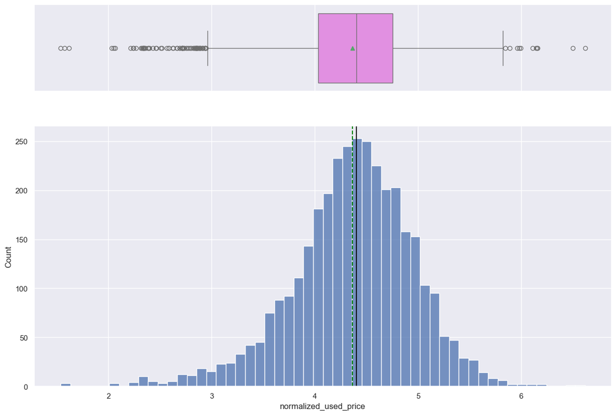

```python
histogram_boxplot(df, "normalized_used_price")
```

##### From the histogram and boxplot of normalized_used_price, we can make the following observations:

##### Distribution Shape: The histogram shows a distribution that is roughly symmetrical and slightly skewed towards the left. Also we can observe that the bulk of the used prices are clustered around the center.

##### Central Tendency: Both the mean (depicted by a green dashed line) and the median (depicted by a black solid line) are very close to each other, located around 4.3 to 4.4, reinforcing the near-symmetrical nature of the distribution. This indicates that the central value of the normalized used price is well-represented by both measures.

##### Also, the prices range from approximately 1.5 to 6.7.

##### Furthermore, the boxplot indicates the presence of some outliers on both the lower and higher ends of the normalized used price scale, suggesting some devices have unusually low or high used prices compared to the majority.

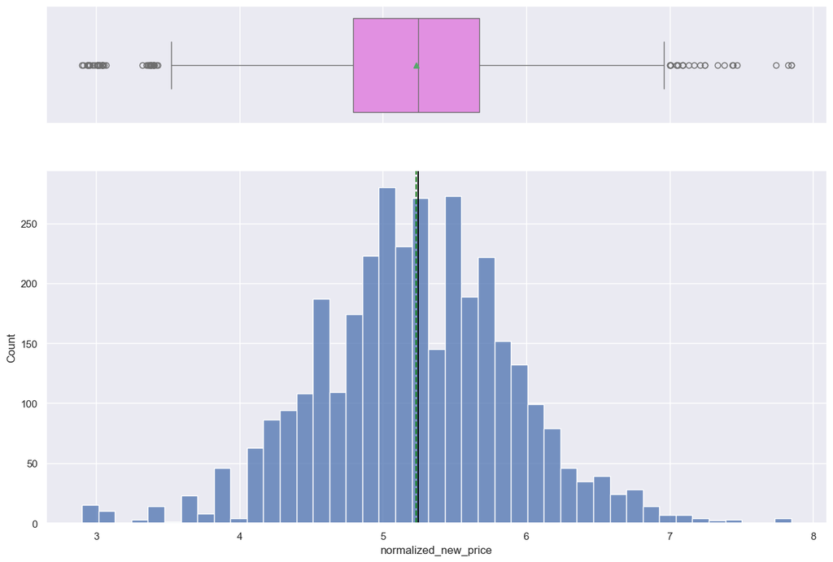

```python
histogram_boxplot(df, "normalized_new_price")
```

#### From the histogram and boxplot for normalized_new_price that have been generated, we can observe that:

##### The distribution of normalized_new_price appears to be slightly left-skewed. Most of the new prices are concentrated around the central values, with a tail extending towards lower prices.

##### The mean (with the green dashed line) and median (with the black solid line) are close, indicating a central value typically around 5.2 to 5.3. This suggests that the average new price is slightly higher than the average used price, which is expected.

##### The new prices range from approximately 2.9 to 7.8, showing a wider spread compared to the used prices, which is also typical, as new products can have a broader range of introductory pricing.

##### The boxplot shows some outliers on both the lower and higher ends, suggesting there are devices with unusually low or high new prices relative to the majority.

## screen_size

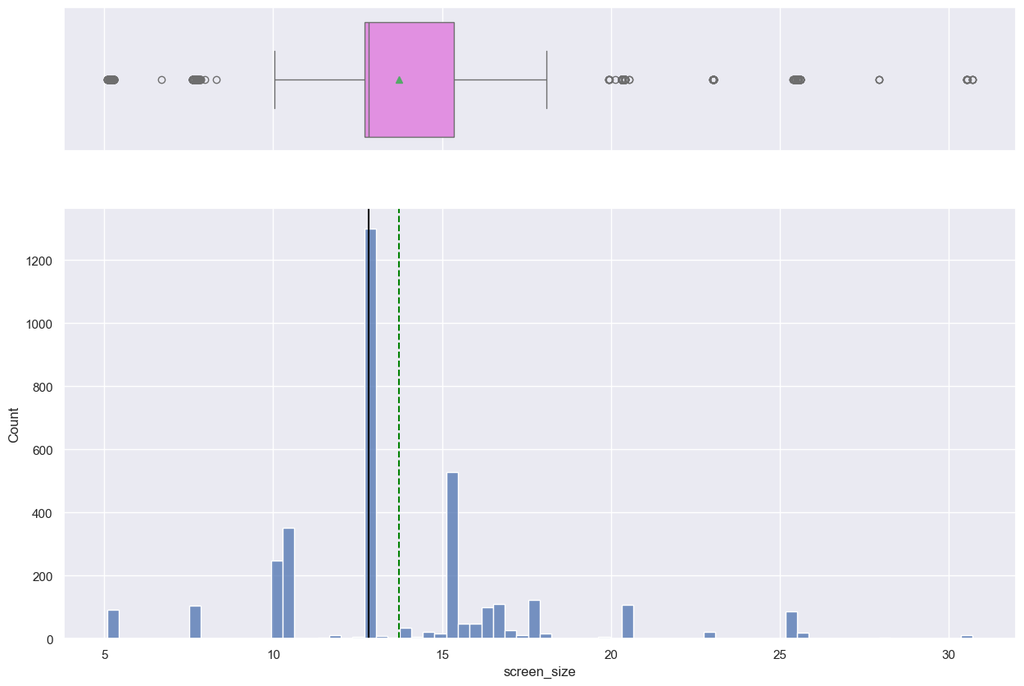

```python
histogram_boxplot(df, "screen_size")
```

#### From the histogram and boxplot for screen_size that have been generated, we can observe that :

##### The histogram shows that screen_size is multimodal, with several peaks. There is an outstanding peak around 12-13 inches, and with the second to it around 15-16 inches, suggesting common screen sizes for different types of devices or models. The distribution also appears to have a long tail towards larger screen sizes.

##### The mean (with the green dashed line) is around 13.7 inches, and the median (with the black solid line) is around 12.83 inches. The difference between the mean and median, along with the multimodal nature, indicates that the distribution is not perfectly symmetric.

##### The screen_size ranges from approximately 5 inches to over 30 inches, showing a very wide spread. This wide range could indicate the presence of different categories of devices within the dataset, such as smartphones, phablets, and tablets.

##### The boxplot indicates the presence of a significant number of outliers on the higher end of the screen size spectrum. These could correspond to larger devices like tablets or other specialized devices, which are considerably larger than the typical screen sizes.

## main_camera_mp

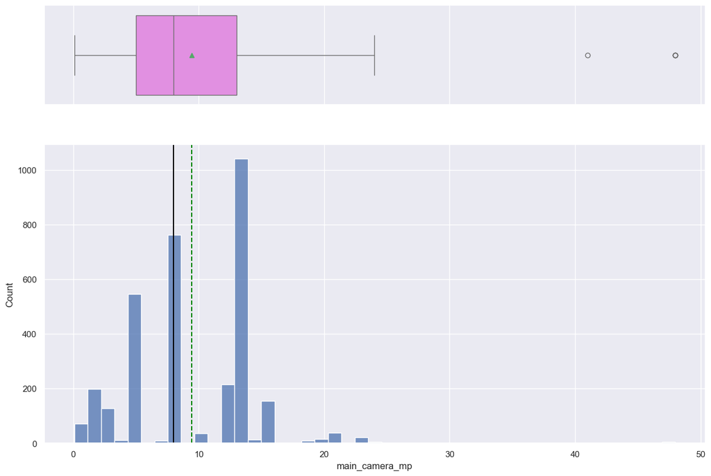

```python
histogram_boxplot(df, "main_camera_mp")
```

#### From the histogram and boxplot for main_camera_mp, we can observe that:

##### The distribution appears to be right-skewed, meaning there are more devices with lower main camera megapixels, and a tail extends towards higher megapixel counts.

##### The mean (wth the green dashed line) is approximately 9.46 MP, while the median (with the black solid line) is 8 MP. The mean being higher than the median confirms the right-skewness.

##### The main camera megapixels range widely, from a minimum of 0.08 MP to a maximum of 48 MP.

##### The boxplot likely indicates some of the outliers on the higher end, corresponding to devices with very high camera specifications compared to the average.

## selfie_camera_mp

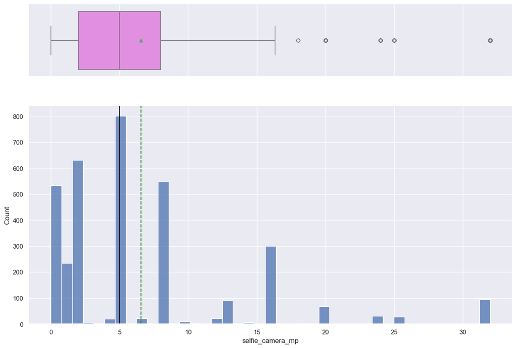

```python
histogram_boxplot(df, "selfie_camera_mp")
```

#### From the histogram and boxplot for selfie_camera_mp, we can observe that:

##### The distribution appears to be right-skewed, similar to the main camera, which gives the indication that more devices have lower selfie camera megapixels, with a tail extending to higher counts.

##### The mean (depicted by a green dashed line) is approximately 6.55 MP, while the median (depicted by a black solid line) is 5 MP. The mean being higher than the median again suggests right-skewness.

##### The selfie camera megapixels range from 0 MP to 32 MP, showing a considerable spread.

##### The boxplot shows some outliers on the higher end, representing devices with particularly high-resolution front-facing cameras.

## int_memory

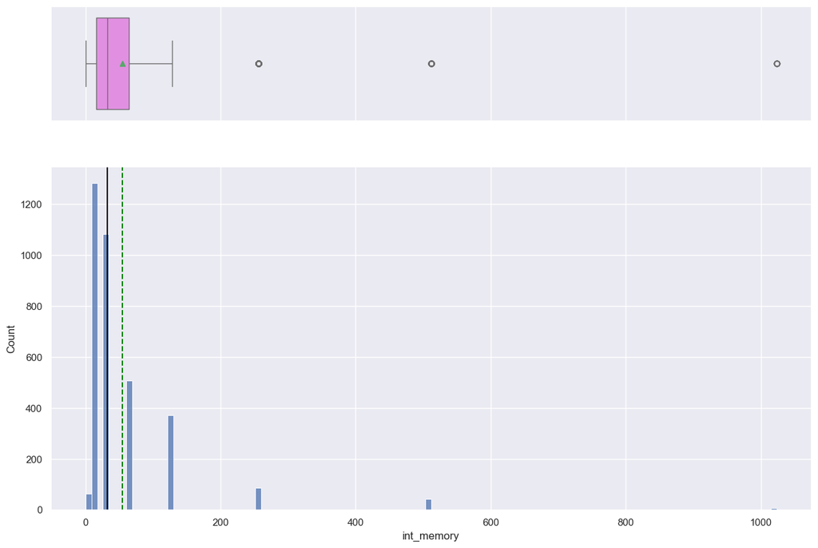

```python
histogram_boxplot(df, "int_memory")
```

#### From the histogram and boxplot for int_memory, we can observe that:

##### The distribution is highly right-skewed, meaning most devices have lower internal memory, with a long tail extending to very high memory capacities.

##### The mean (depicted by green dashed line), around 54.57 GB, is significantly higher than the median (black solid line), which is 32 GB. This large difference further confirms the strong right-skewness caused by a few devices with very large internal memory.

##### The internal memory ranges widely from a minimum of 0.01 GB to a maximum of 1024 GB.

##### The boxplot clearly shows some outliers on the higher end, corresponding to devices with unusually large internal memory, consistent with the right-skewed distribution.

## ram

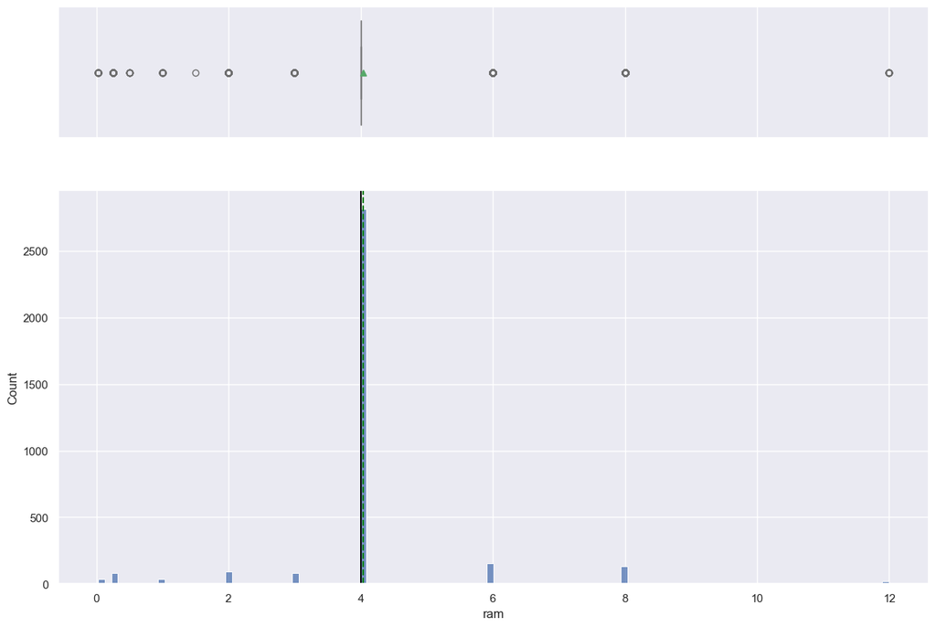

```python
histogram_boxplot(df, "ram")
```

#### From the histogram and boxplot for ram, we can observe that:

##### The mean ram seems to be slightly higher than the median, due to the right-skewness. This is based on previous data.describe() output, where the mean is around 4.03 GB, and the median is 4 GB, which are very close, indicating a cluster around 4GB.

##### The ram ranges from 0.02 GB to 12 GB, showing a decent spread but with most values concentrated at the lower end.

##### The boxplot seems to show some outliers on the higher end, corresponding to devices with very large ram capacities.

## weight

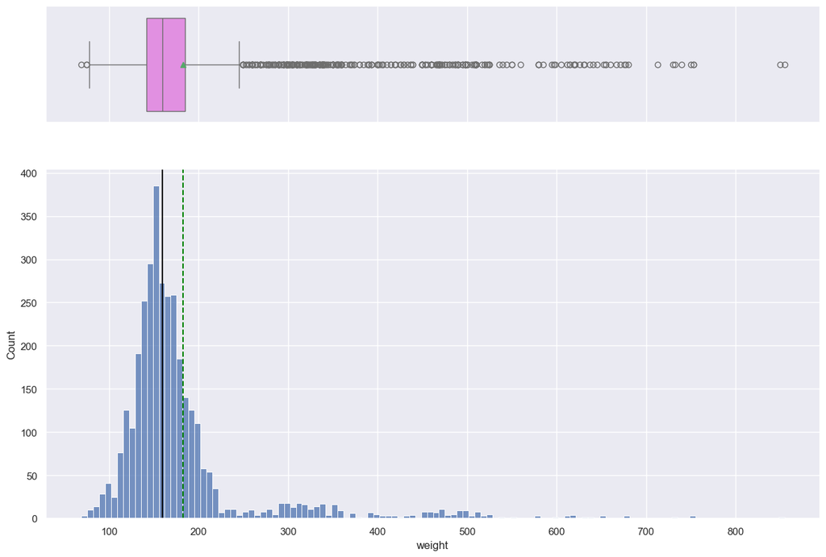

```python
histogram_boxplot(df, "weight")
```

##### From the histogram and boxplot for weight, I observe the following:

##### The distribution of weight appears to be right-skewed, meaning most devices have lower weights, with a long tail extending towards heavier devices.

##### The mean (depicted by a green dashed line), around 182.75 g, is higher than the median (depicted by a black solid line), which is 160 g. This difference confirms the right-skewness, suggesting that the average weight is pulled up by a few heavier devices.

##### The weight ranges significantly, from 69 g to 855 g. This wide range suggests the dataset includes various types of devices, from very light smartphones to potentially heavier tablets or other devices.

##### The boxplot clearly indicates a number of outliers on the higher end of the weight spectrum, corresponding to devices that are considerably heavier than the majority. These might represent larger devices or devices with robust designs.

## battery

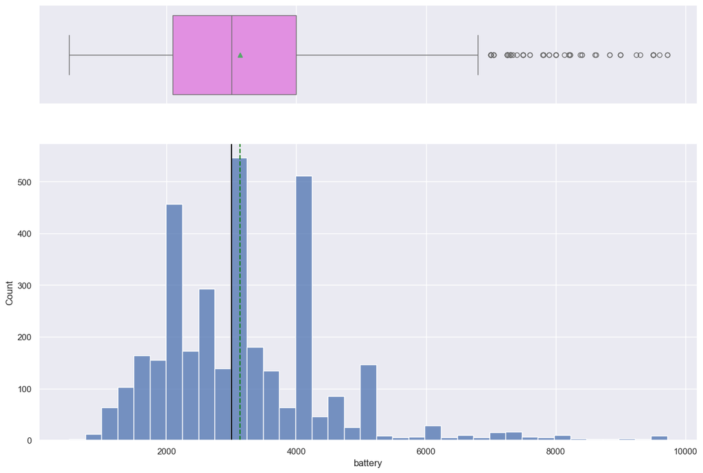

```python
histogram_boxplot(df, "battery")
```

#### From the histogram and boxplot for battery, we can observe that:

##### The distribution appears to be generally symmetric with a slight right-skew. Most devices have battery capacities clustered around the mean and median, with a tail extending towards higher capacities.

##### The mean (which is a green dashed line) is approximately 3133.4 mAh, and the median (depicted by a black solid line) is 3000 mAh. These values are very close, indicating a central tendency around 3000-3100 mAh.

##### The battery capacities range from a minimum of 500 mAh to a maximum of 9720 mAh, showing a wide spread.

##### The boxplot indicates the presence of several outliers on the higher end, corresponding to devices with unusually large battery capacities.

## days_used

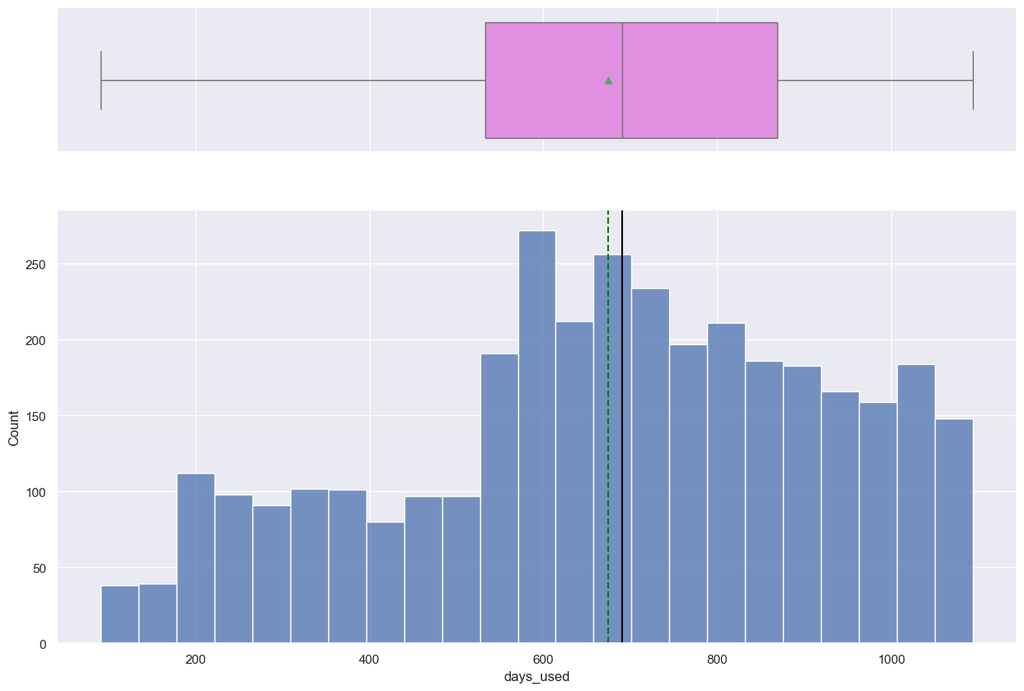

```python
histogram_boxplot(df, "days_used")
```

## brand_name

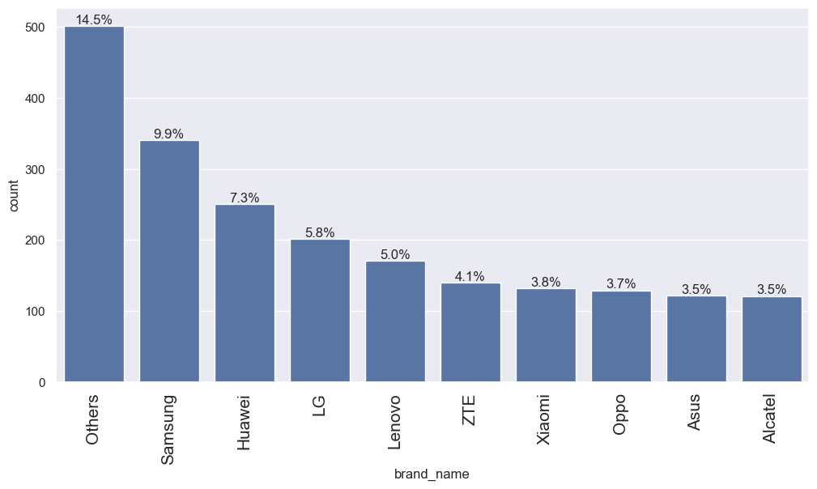

```python
labeled_barplot(df, "brand_name", perc=True, n=10)
```

#### From the barplot for brand_name, we cab observe that:

##### The plot displays the top 10 most frequent brand names in the dataset.

##### The 'Others' category represents a significant portion of the data, accounting for approximately 14.5% of all devices. This indicates that a large number of less common brands are grouped under this category.

##### There are also leading individual brands, after 'Others', with 'Samsung' being the most frequent individual brand, making up about 9.9% of the dataset, followed closely by 'Huawei' (around 7.3%) and 'LG' (about 5.8%).

##### Note that, while a few brands dominate, the presence of 34 unique brands (as noted in the data.describe() output) suggests a diverse market, but the plot highlights the most popular ones.

## os

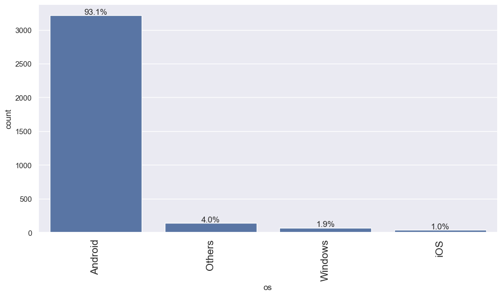

```python
labeled_barplot(df, "os", perc=True, n=10)
```

#### From the barplot for os, we can observe that:

##### The plot clearly shows a very limited diversity in operating systems within this dataset, with Android being the overwhelming choice.

## 4g

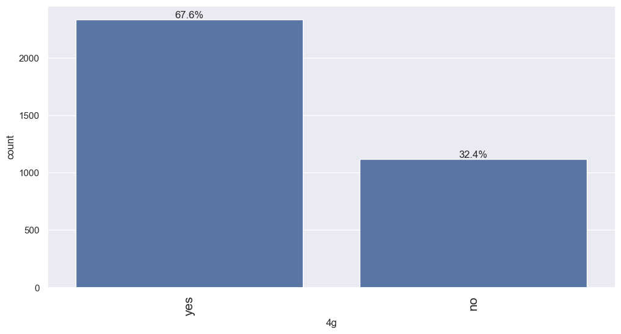

```python
labeled_barplot(df, "4g", perc=True, n=10)
```

#### From the barplot for 4g, we can observe that :

##### The majority of devices in the dataset support 4G. Approximately 67.6% of the devices have 'yes' for 4G connectivity, while 32.4% have 'no'. This indicates that 4G is a widely adopted feature among the devices in this dataset.

## 5g

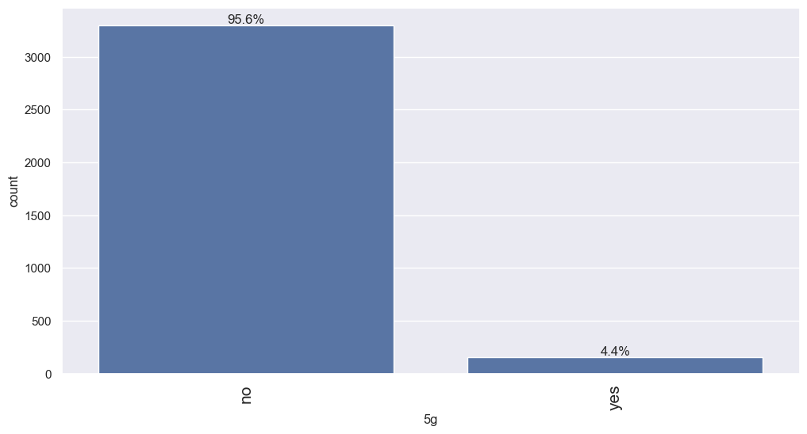

```python
labeled_barplot(df, "5g", perc=True, n=10)
```

#### From the barplot for 5g, we can observe that:

##### The vast majority of devices in the dataset do not support 5G. Approximately 95.6% of the devices have 'no' for 5G connectivity, while only 4.4% have 'yes'. This indicates that 5G is a relatively new or less common feature among the devices in this dataset, especially when compared to 4G adoption.

## released_year

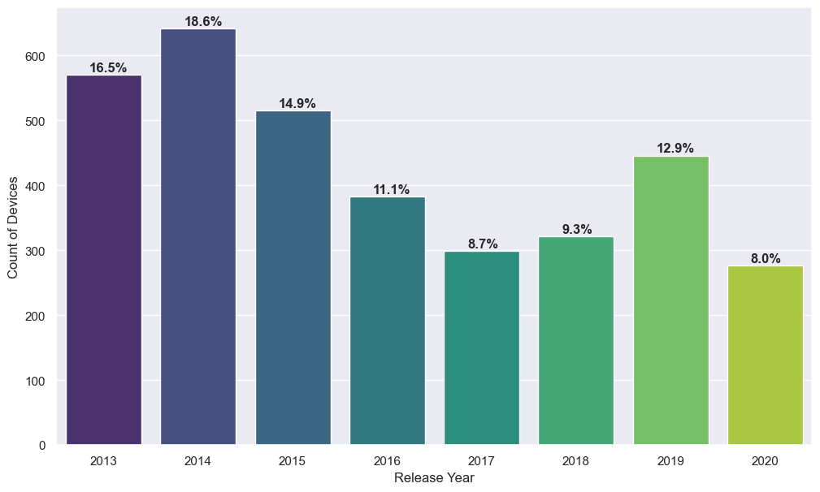

```python
# 1. Set the figure size
plt.figure(figsize=(12, 7))

# 2. Create the countplot
ax = sns.countplot(data=df, x='release_year', palette='viridis')

# 3. Calculate total number of data points for percentage calculation
total = len(df)

# 4. Add percentages to the bars
for p in ax.patches:
    # Calculate percentage
    percentage = '{:.1f}%'.format(100 * p.get_height() / total)

    # Get coordinates for the text
    x = p.get_x() + p.get_width() / 2 - 0.15 # Center the text
    y = p.get_height() + 5                   # Position text slightly above the bar

    # Annotate the bar
    ax.annotate(percentage, (x, y), size=12, fontweight='bold')

# 5. Add labels and title
plt.xlabel('Release Year', fontsize=12)
plt.ylabel('Count of Devices', fontsize=12)

# Show the plot
plt.show()
```

#### From the above barplot for release_year, w can observe that:

##### Over 50% of the devices in the dataset were released in the three-year span between 2013 and 2015 (approx. 16.5%, 18.6%, and 14.9%, respectively).

##### Devices from 2020, which seem to be the recent models, make up only about 8.0% of the total data, which is the smallest segment.

##### Also, ReCell's current business model seems heavily reliant on older hardware (6+ years old). Expanding the 2018–2020 inventory could be a major growth opportunity, as those devices carry higher resale values.

## Bivariate Analysis

### We will now focus on Correlation Check

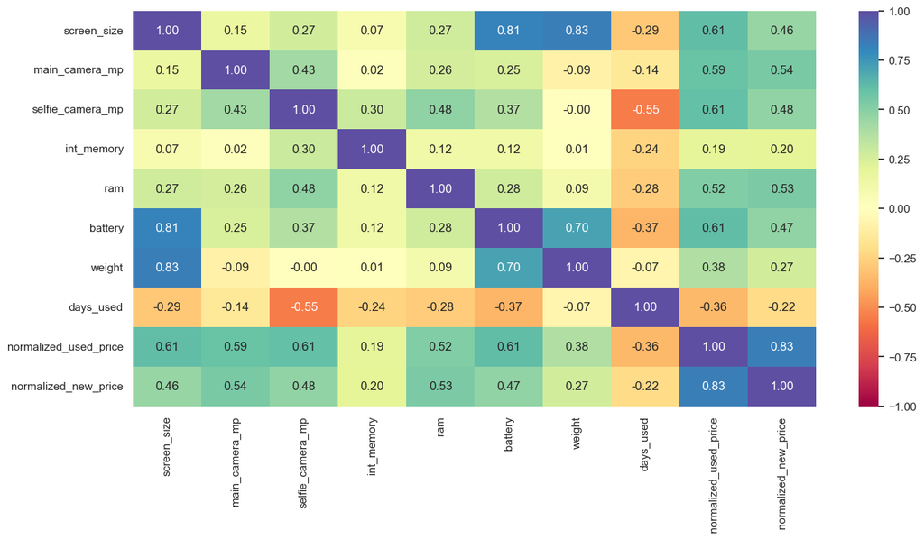

```python
cols_list = df.select_dtypes(include=np.number).columns.tolist()
# dropping release_year as it is a temporal variable
cols_list.remove("release_year")

plt.figure(figsize=(15, 7))
sns.heatmap(
    df[cols_list].corr(), annot=True, vmin=-1, vmax=1, fmt=".2f", cmap="Spectral"
)
plt.show()
```

#### This heatmap provides a visual summary of how the different numeric features in the ReCell dataset relate to each other. Observations we can make from this analysis:

##### The normalized_new_price has the strongest positive correlation (0.83) with normalized_used_price.

##### There is a strong "cluster" of features that all correlate positively with each other and the target price:

##### The Screen Size (0.61), Battery (0.61), and Selfie Camera (0.61) are all strong predictors of a higher normalized_used_price.

##### The days_used also shows a negative correlation (-0.36) with the normalized_used_price.This is the "depreciation factor." For every additional day a device is used, its value tends to drop.

##### Also, the Screen Size & Weight gives us (0.83), meaning that larger devices are heavier.

##### The Screen Size & Battery gives us (0.81), meaning Larger phones have more physical space for bigger batteries.

##### int_memory (Internal Memory) has a surprisingly low correlation (0.19) normalized_used_price compared to ram and normalized_used_price (0.52). it means that in the used market, performance of the (RAM) seems to be a much bigger value driver for consumers than storage capacity (Internal Memory).

##### Screen Size & Weight (0.83): This makes physical sense; larger devices are heavier.

## The amount of RAM is important for the smooth functioning of a device.

## Let's see how the amount of RAM varies across brands

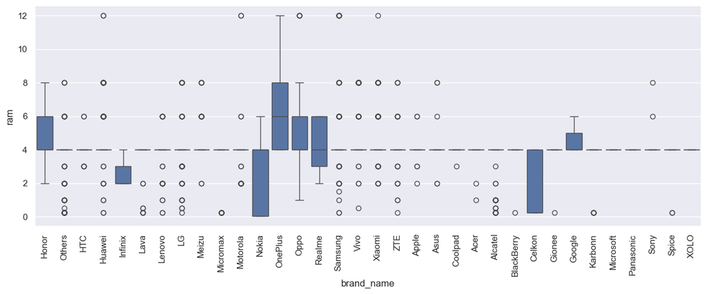

```python
plt.figure(figsize=(15, 5))
sns.boxplot(data=df, x="brand_name", y="ram")
plt.xticks(rotation=90)
plt.show()
```

#### Let us look at the Key Observations that can be made from the Plot:

##### OnePlus stands out with the highest median RAM (6.0 GB), indicating its focus on high-performance devices.

##### Brands like Samsung, Oppo, and Motorola offer a wide range of RAM options (up to 12 GB), reflecting a diverse product portfolio that spans from budget to flagship devices.

##### Also, a large majority of brands (including Apple, Huawei, Nokia, and Xiaomi) have a median RAM of 4.0 GB. This appears to be the standard requirement for the most used devices in the current market.

##### Brands like Celkon and Infinix have significantly lower median RAM (0.25 GB to 2.0 GB). These represent the entry-level or older segment of the used device market.

## People who travel frequently require devices with large batteries to run through the day.

### But a large battery often increases weight, making it feel uncomfortable in the hands.

```python
df_large_battery = df[df.battery > 4500]
df_large_battery.shape
```

```
(341, 15)
```

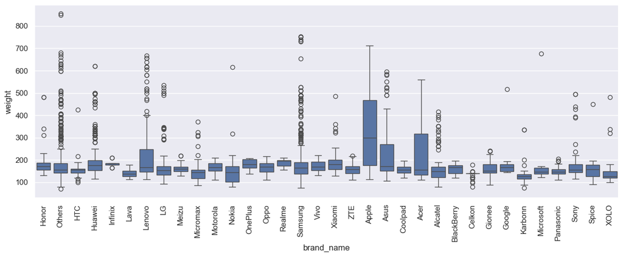

```python
plt.figure(figsize=(15, 5))
sns.boxplot(data=df, x="brand_name", y="weight")
plt.xticks(rotation=90)
plt.show()
```

#### Key Observations from the Plot:

##### Apple has the highest median weight (~299g) among the top brands shown, likely due to a high proportion of tablets or "Pro Max" style devices in the used market.

##### You can also see that most smartphone-centric brands like Realme, Infinix, Xiaomi, and Oppo have their median weight clustered between 160g and 195g.

##### From our previous heatmap, we notice that Weight is highly correlated with Screen Size ($0.83$). This depicts that brands with higher median weights are almost certainly the ones offering a larger screen.

## People who buy phones and tablets primarily for entertainment purposes prefer a large screen as they offer a better viewing experience.

### We will now create a new dataframe of only those devices that are suitable for such people and analyze.

```python
df_large_screen = df[df.screen_size > 6 * 2.54]
df_large_screen.shape
```

```
(1099, 15)
```

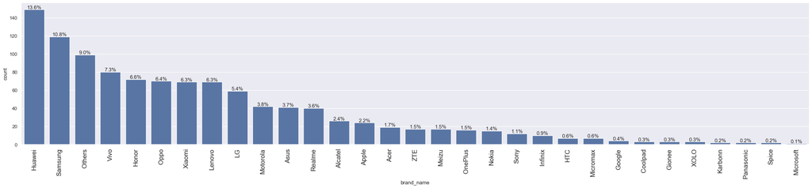

```python
# Create labeled_barplot for 'brand_name' in the large screen dataframe
labeled_barplot(df_large_screen, 'brand_name', perc=True)
```

#### Analysis of Large Screen Devices:

##### There are indications that 1,099 devices in the dataset have screen sizes larger than 6 inches, making up roughly 31.8% of the total inventory.

##### Leading brands like Huawei, Samsung, Vivo, and Honor dominate this segment. This indicates that these manufacturers prioritized the "phablet" and tablet market earlier than others.

##### furthermore because these devices are larger, they are often associated with higher battery capacities and weights, confirming they are built for long-duration activities like video streaming or gaming.

## Everyone likes a good camera to capture their favorite moments with loved ones. Some customers specifically look for good front cameras to click cool selfies.

### We will now create a new dataframe of only those devices that are suitable for this customer segment and analyze.

```python
df_selfie_camera = df[df.selfie_camera_mp > 8]
df_selfie_camera.shape
```

```
(655, 15)
```

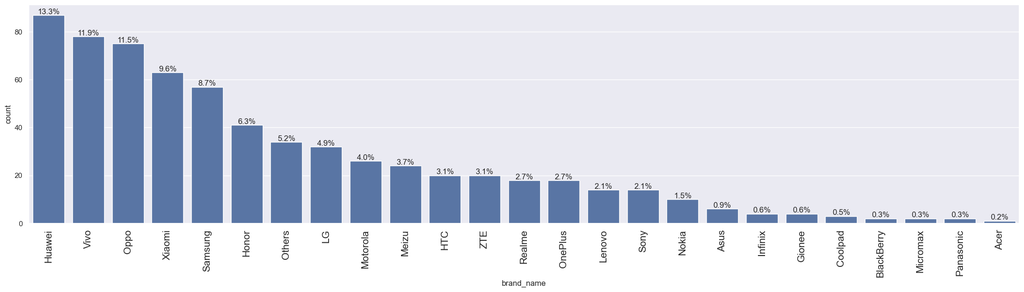

```python
labeled_barplot(df_selfie_camera, 'brand_name', perc=True)
```

##### Observations from the High Selfie Camera Segment size depict that there are 655 devices in the dataset that cater to selfie enthusiasts. This represents a more niche but premium segment of the market compared to the large-screen segment.

##### Dominant brands are Huawei (13.3%), Vivo (11.9%), and Oppo (11.5%), which are the clear leaders in this category.

##### While Samsung is a market leader overall, it ranks 5th in this specific segment (8.7%). This indicates that during the years represented in the data, Chinese manufacturers were more aggressive in pushing high-megapixel front cameras.

##### High-megapixel front cameras are often associated with newer models. Our previous correlation analysis, thus the heatmap showed that selfie_camera_mp has a strong positive correlation (0.61) with the used price. Therefore, these 655 devices likely represent a high-value portion of ReCell’s inventory.

## Let's do a similar analysis for rear cameras.

### Rear cameras generally have a better resolution than front cameras, so we set the threshold higher for them at 16MP.

```python
df_main_camera = df[df.main_camera_mp > 16]
df_main_camera.shape
```

```
(94, 15)
```

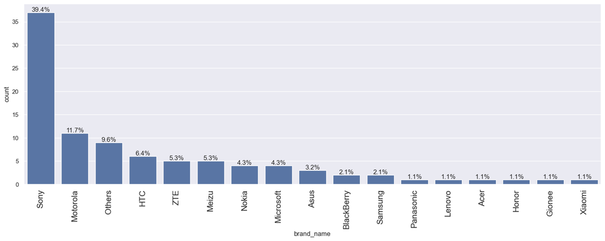

```python
labeled_barplot(df_main_camera, 'brand_name', perc=True)
```

#### Observations from the High Main Camera Segmen depicts that

###### There are only 94 devices in the entire dataset with a main camera resolution greater than 16MP. This is a very small and exclusive segment (roughly 2.7% of the data).

##### We can also see that Sony is the overwhelming leader in this category, accounting for nearly 39.4% of all high-resolution main camera devices in the dataset. This reflects Sony’s industry position as a primary manufacturer of camera sensors.

##### Furthermore, Motorola (11.7%) and HTC (6.4%) also appear in the top list, showing that they historically competed in the high-megapixel photography space.

##### In our heatmap, main_camera_mp had a strong correlation (0.59) with the used price. Even though this group is small, these 94 devices can be said to have some of the highest predicted resale values in the inventory.

## Let's see how the price of used devices varies across the years

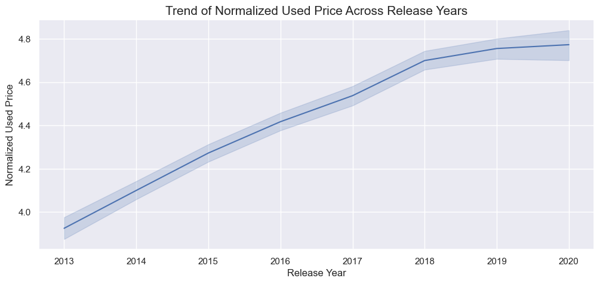

```python
plt.figure(figsize=(12, 5))

# Complete the lineplot call
sns.lineplot(data=df, x="release_year", y="normalized_used_price")

# Adding title and labels for clarity
plt.title('Trend of Normalized Used Price Across Release Years', fontsize=15)
plt.xlabel('Release Year', fontsize=12)
plt.ylabel('Normalized Used Price', fontsize=12)

plt.show()
```

#### Observations from the Line Plot depict that

##### There is a clear and consistent increase in the normalized_used_price as the release_year progresses. This confirms that newer models retain significantly higher value in the resale market.

##### There is also Price Appreciation, such that in 2013, the average normalized price was approximately 3.93, and by 2020, it reached approximately 4.77.

## Let's check how the prices vary for used phones and tablets offering 4G and 5G networks.

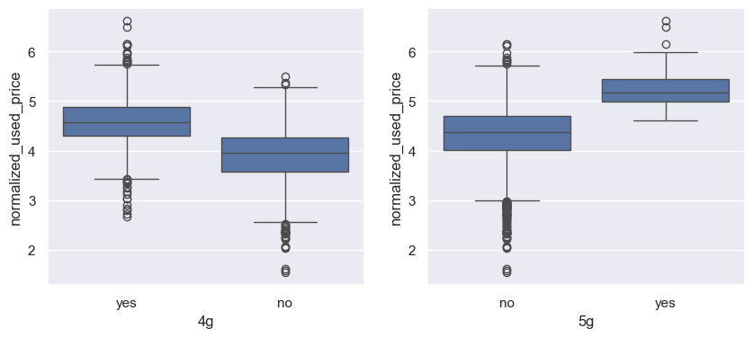

```python
plt.figure(figsize=(10, 4))

plt.subplot(121)
sns.boxplot(data=df, x="4g", y="normalized_used_price")

plt.subplot(122)
sns.boxplot(data=df, x="5g", y="normalized_used_price")

plt.show()
```

## Data Preprocessing

### We will impute the missing values in the data by the column medians grouped by release_year and brand_name.

```python
# let's create a copy of the data
df1 = df.copy()
```

```python
df1.isnull().sum()
```

```
brand_name                 0
os                         0
screen_size                0
4g                         0
5g                         0
main_camera_mp           179
selfie_camera_mp           2
int_memory                 4
ram                        4
battery                    6
weight                     7
release_year               0
days_used                  0
normalized_used_price      0
normalized_new_price       0
dtype: int64
```

```python
cols_impute = [
    "main_camera_mp",
    "selfie_camera_mp",
    "int_memory",
    "ram",
    "battery",
    "weight",
]

for col in cols_impute:
    df1[col] = df1[col].fillna(
        value=df1.groupby(['brand_name', 'release_year'])[col].transform("median")
    )

# checking for missing values after imputing the above columns
df1.isnull().sum()
```

```
brand_name                 0
os                         0
screen_size                0
4g                         0
5g                         0
main_camera_mp           179
selfie_camera_mp           2
int_memory                 0
ram                        0
battery                    6
weight                     7
release_year               0
days_used                  0
normalized_used_price      0
normalized_new_price       0
dtype: int64
```

## We will impute the remaining missing values in the data by the column medians grouped by brand_name.

```python
cols_impute = [
    "main_camera_mp",
    "selfie_camera_mp",
    "battery",
    "weight",
]

for col in cols_impute:
    df1[col] = df1[col].fillna(
        value=df1.groupby(['brand_name'])[col].transform("median")
    )

# checking for missing values after imputing the above columns
df1.isnull().sum()
```

```
brand_name                0
os                        0
screen_size               0
4g                        0
5g                        0
main_camera_mp           10
selfie_camera_mp          0
int_memory                0
ram                       0
battery                   0
weight                    0
release_year              0
days_used                 0
normalized_used_price     0
normalized_new_price      0
dtype: int64
```

## We will fill the remaining missing values in the main_camera_mp column by the column median.

```python
# Final pass: fill remaining missing values with the overall column median
df1["main_camera_mp"] = df1["main_camera_mp"].fillna(df1["main_camera_mp"].median())

# checking for missing values after imputing the above columns
df1.isnull().sum()
```

```
brand_name               0
os                       0
screen_size              0
4g                       0
5g                       0
main_camera_mp           0
selfie_camera_mp         0
int_memory               0
ram                      0
battery                  0
weight                   0
release_year             0
days_used                0
normalized_used_price    0
normalized_new_price     0
dtype: int64
```

#### All the missing values have been treated.

## Feature Engineering

### Let's create a new column years_since_release from the release_year column.

### We will consider the year of data collection, 2021, as the baseline.

### We will drop the release_year column.

```python
df1["years_since_release"] = 2021 - df1["release_year"]
df1.drop("release_year", axis=1, inplace=True)
df1["years_since_release"].describe()
```

```
count    3454.000000
mean        5.034742
std         2.298455
min         1.000000
25%         3.000000
50%         5.500000
75%         7.000000
max         8.000000
Name: years_since_release, dtype: float64
```

#### From the descriptive statistics of the years_since_release column, we can observe that:

##### There are 3454 entries, matching the total number of devices in the dataset.

##### On average, devices in this dataset were released approximately 5 years ago (5.03 years since 2021).

##### The standard deviation is 2.29 years, indicating a moderate spread around the mean.

##### The newest devices were released 1 year ago (in 2020).

##### 25% of the devices were released 3 years ago or less (in 2018 or later).

##### The median age of devices is 5.5 years, meaning half of the devices were released 5.5 years ago or less (mid-2015 or later).

##### 75% of the devices were released 7 years ago or less (in 2014 or later).

##### The oldest devices were released 8 years ago (in 2013).

## Outlier Check

### Let's check for outliers in the data.

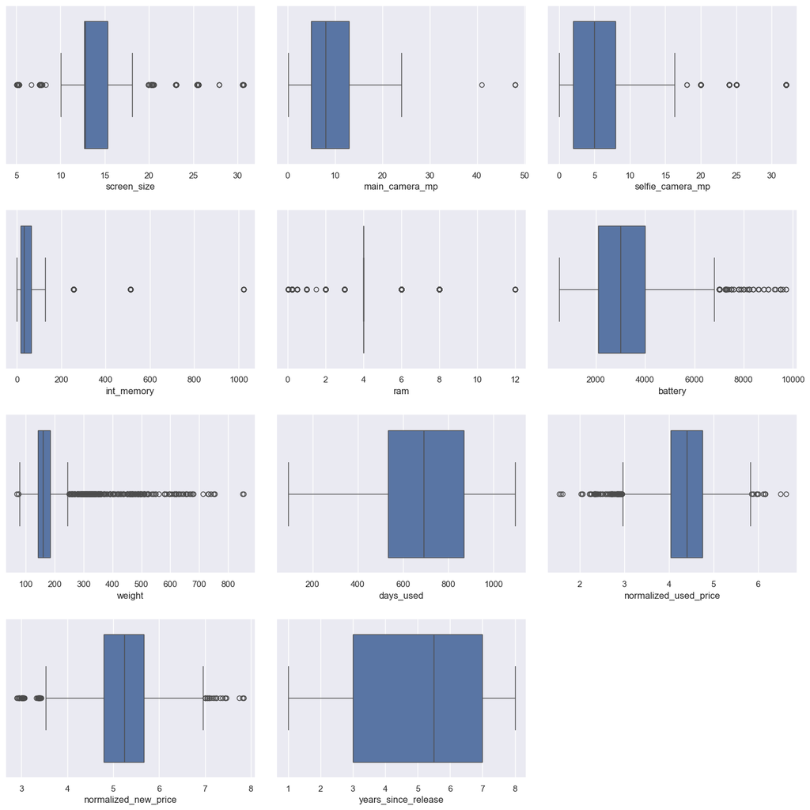

```python
# outlier detection using boxplot
num_cols = df1.select_dtypes(include=np.number).columns.tolist()

plt.figure(figsize=(15, 15))

for i, variable in enumerate(num_cols):
    plt.subplot(4, 3, i + 1)
    sns.boxplot(data=df1, x=variable)
    plt.tight_layout(pad=2)

plt.show()
```

#### From the Observations we can see that :

##### Weight & Screen Size: You will likely see significant outliers on the higher end here as well.These are likely tablets (iPads, etc.) which are naturally much heavier and larger than the standard smartphone.

##### Several features exhibit a right-skewed distribution with a significant number of outliers on the higher end. This includes main_camera_mp, selfie_camera_mp, int_memory, battery, weight, and screen_size. These outliers often represent premium, high-specification devices (e.g., devices with very large screens, high-megapixel cameras, or extensive memory/RAM).

##### normalized_used_price and normalized_new_price: Both price columns show some outliers on both the lower and higher ends, indicating devices with unusually low or high prices compared to the bulk of the data.

##### years_since_releaseThis column rarely has outliers because the range is strictly bounded between 1 and 8 years.

## Data Preparation for modeling.

#### We will then want to predict the normalized price of used devices.

#### Before we proceed to build a model, we'll have to encode categorical features

#### We'll then split the data into train and test to be able to evaluate the model that we build on the train data

#### finally, we will build a Linear Regression model using the train data and then check its performance

```python
# Define the dependent variable
y = df1["normalized_used_price"]

# Define the independent variables (drop the target column)
# We also drop 'brand_name' if you haven't encoded it yet,
# as Linear Regression cannot handle raw strings.
X = df1.drop(["normalized_used_price"], axis=1)

print("Independent Variables (X):")
print(X.head())
print("\nDependent Variable (y):")
print(y.head())
```

```
Independent Variables (X):
  brand_name       os  screen_size   4g   5g  main_camera_mp  \
0      Honor  Android        14.50  yes   no            13.0
1      Honor  Android        17.30  yes  yes            13.0
2      Honor  Android        16.69  yes  yes            13.0
3      Honor  Android        25.50  yes  yes            13.0
4      Honor  Android        15.32  yes   no            13.0

   selfie_camera_mp  int_memory  ram  battery  weight  days_used  \
0               5.0        64.0  3.0   3020.0   146.0        127
1              16.0       128.0  8.0   4300.0   213.0        325
2               8.0       128.0  8.0   4200.0   213.0        162
3               8.0        64.0  6.0   7250.0   480.0        345
4               8.0        64.0  3.0   5000.0   185.0        293

   normalized_new_price  years_since_release
0              4.715100                    1
1              5.519018                    1
2              5.884631                    1
3              5.630961                    1
4              4.947837                    1

Dependent Variable (y):
0    4.307572
1    5.162097
2    5.111084
3    5.135387
4    4.389995
Name: normalized_used_price, dtype: float64
```

```python
# let's add the intercept to data
X = sm.add_constant(X)
```

```python
# creating dummy variables
X = pd.get_dummies(
    X,
    columns=X.select_dtypes(include=["object", "category"]).columns.tolist(),
    drop_first=True,
)  ## Completed: used get_dummies to transform categorical variables

# Display the first few rows of the transformed dataframe
X.head()
```

|  | const | screen_size | main_camera_mp | selfie_camera_mp | int_memory | ram | battery | weight | days_used | normalized_new_price | ... | brand_name_Spice | brand_name_Vivo | brand_name_XOLO | brand_name_Xiaomi | brand_name_ZTE | os_Others | os_Windows | os_iOS | 4g_yes | 5g_yes |
| --- | --- | --- | --- | --- | --- | --- | --- | --- | --- | --- | --- | --- | --- | --- | --- | --- | --- | --- | --- | --- | --- |
| 0 | 1.0 | 14.50 | 13.0 | 5.0 | 64.0 | 3.0 | 3020.0 | 146.0 | 127 | 4.715100 | ... | False | False | False | False | False | False | False | False | True | False |
| 1 | 1.0 | 17.30 | 13.0 | 16.0 | 128.0 | 8.0 | 4300.0 | 213.0 | 325 | 5.519018 | ... | False | False | False | False | False | False | False | False | True | True |
| 2 | 1.0 | 16.69 | 13.0 | 8.0 | 128.0 | 8.0 | 4200.0 | 213.0 | 162 | 5.884631 | ... | False | False | False | False | False | False | False | False | True | True |
| 3 | 1.0 | 25.50 | 13.0 | 8.0 | 64.0 | 6.0 | 7250.0 | 480.0 | 345 | 5.630961 | ... | False | False | False | False | False | False | False | False | True | True |
| 4 | 1.0 | 15.32 | 13.0 | 8.0 | 64.0 | 3.0 | 5000.0 | 185.0 | 293 | 4.947837 | ... | False | False | False | False | False | False | False | False | True | False |

5 rows × 49 columns

```python
# Splitting the data into 70% training and 30% testing
x_train, x_test, y_train, y_test = train_test_split(X, y, test_size=0.30, random_state=1)
```

```python
print("Number of rows in train data =", x_train.shape[0])
print("Number of rows in test data =", x_test.shape[0])
```

```
Number of rows in train data = 2417
Number of rows in test data = 1037
```

## Model Building - Linear Regression

```python
# 1. Convert any boolean or object columns to numeric
x_train = x_train.astype(float)
x_test = x_test.astype(float)

# 2. (Optional but recommended) Add the constant if you haven't yet
# statsmodels needs this to calculate the intercept
import statsmodels.api as sm
x_train = sm.add_constant(x_train)

# 3. Fit the model again
olsmodel1 = sm.OLS(y_train, x_train).fit()
print(olsmodel1.summary())
```

```
                              OLS Regression Results
=================================================================================
Dep. Variable:     normalized_used_price   R-squared:                       0.845
Model:                               OLS   Adj. R-squared:                  0.842
Method:                    Least Squares   F-statistic:                     268.7
Date:                   Fri, 20 Feb 2026   Prob (F-statistic):               0.00
Time:                           08:15:37   Log-Likelihood:                 123.85
No. Observations:                   2417   AIC:                            -149.7
Df Residuals:                       2368   BIC:                             134.0
Df Model:                             48
Covariance Type:               nonrobust
=========================================================================================
                            coef    std err          t      P>|t|      [0.025      0.975]
-----------------------------------------------------------------------------------------
const                     1.3156      0.071     18.454      0.000       1.176       1.455
screen_size               0.0244      0.003      7.163      0.000       0.018       0.031
main_camera_mp            0.0208      0.002     13.848      0.000       0.018       0.024
selfie_camera_mp          0.0135      0.001     11.997      0.000       0.011       0.016
int_memory                0.0001   6.97e-05      1.651      0.099   -2.16e-05       0.000
ram                       0.0230      0.005      4.451      0.000       0.013       0.033
battery               -1.689e-05   7.27e-06     -2.321      0.020   -3.12e-05   -2.62e-06
weight                    0.0010      0.000      7.480      0.000       0.001       0.001
days_used              4.216e-05   3.09e-05      1.366      0.172   -1.84e-05       0.000
normalized_new_price      0.4311      0.012     35.147      0.000       0.407       0.455
years_since_release      -0.0237      0.005     -5.193      0.000      -0.033      -0.015
brand_name_Alcatel        0.0154      0.048      0.323      0.747      -0.078       0.109
brand_name_Apple         -0.0038      0.147     -0.026      0.980      -0.292       0.285
brand_name_Asus           0.0151      0.048      0.314      0.753      -0.079       0.109
brand_name_BlackBerry    -0.0300      0.070     -0.427      0.669      -0.168       0.108
brand_name_Celkon        -0.0468      0.066     -0.707      0.480      -0.177       0.083
brand_name_Coolpad        0.0209      0.073      0.287      0.774      -0.122       0.164
brand_name_Gionee         0.0448      0.058      0.775      0.438      -0.068       0.158
brand_name_Google        -0.0326      0.085     -0.385      0.700      -0.199       0.133
brand_name_HTC           -0.0130      0.048     -0.270      0.787      -0.108       0.081
brand_name_Honor          0.0317      0.049      0.644      0.520      -0.065       0.128
brand_name_Huawei        -0.0020      0.044     -0.046      0.964      -0.089       0.085
brand_name_Infinix        0.1633      0.093      1.752      0.080      -0.019       0.346
brand_name_Karbonn        0.0943      0.067      1.405      0.160      -0.037       0.226
brand_name_LG            -0.0132      0.045     -0.291      0.771      -0.102       0.076
brand_name_Lava           0.0332      0.062      0.533      0.594      -0.089       0.155
```

[output cut: 19 more lines]

```
os_Windows               -0.0207      0.045     -0.459      0.646      -0.109       0.068
os_iOS                   -0.0663      0.146     -0.453      0.651      -0.354       0.221
4g_yes                    0.0528      0.016      3.326      0.001       0.022       0.084
5g_yes                   -0.0714      0.031     -2.268      0.023      -0.133      -0.010
==============================================================================
Omnibus:                      223.612   Durbin-Watson:                   1.910
Prob(Omnibus):                  0.000   Jarque-Bera (JB):              422.275
Skew:                          -0.620   Prob(JB):                     2.01e-92
Kurtosis:                       4.630   Cond. No.                     1.78e+05
==============================================================================

Notes:
[1] Standard Errors assume that the covariance matrix of the errors is correctly specified.
[2] The condition number is large, 1.78e+05. This might indicate that there are
strong multicollinearity or other numerical problems.
```

#### Let's interpret the Ordinary Least Squares (OLS) regression results for predicting normalized_used_price:

##### const.coefficient: this is the Y-intercept. The const coefficient, which is 1.3156 is the predicted normalized_used_price when all other numerical independent variables are zero, and all categorical dummy variables are at their baseline level.

##### Coefficient of a predictor variable: It represents the change in the output Y due to a change in the predictor variable (everything else held constant).In our case, the coefficient of normalized_new_price is 0.4311.

##### We can also deduce in conclusion that the model provides a strong explanation of used device prices, primarily driven by the normalized_new_price, and key hardware specifications like RAM, screen size, and camera megapixels. Device age (years_since_release) is a significant factor in depreciation. The insignificance of days_used and many brand/OS dummies suggests their effects are either minimal or largely captured by other, more influential variables in the model.

## Model Performance Check

### Let's check the performance of the model using different metrics.

### We will be using metric functions defined in sklearn for RMSE, MAE, and R2

### We will define a function to calculate MAPE and adjusted R2

### We will create a function that will print out all the above metrics in one go.

```python
# function to compute adjusted R-squared
def adj_r2_score(predictors, targets, predictions):
    r2 = r2_score(targets, predictions)
    n = predictors.shape[0]
    k = predictors.shape[1]
    return 1 - ((1 - r2) * (n - 1) / (n - k - 1))


# function to compute MAPE
def mape_score(targets, predictions):
    return np.mean(np.abs(targets - predictions) / targets) * 100


# function to compute different metrics to check performance of a regression model
def model_performance_regression(model, predictors, target):
    """
    Function to compute different metrics to check regression model performance

    model: regressor
    predictors: independent variables
    target: dependent variable
    """

    # predicting using the independent variables
    pred = model.predict(predictors)

    r2 = r2_score(target, pred)  # to compute R-squared
    adjr2 = adj_r2_score(predictors, target, pred)  # to compute adjusted R-squared
    rmse = np.sqrt(mean_squared_error(target, pred))  # to compute RMSE
    mae = mean_absolute_error(target, pred)  # to compute MAE
    mape = mape_score(target, pred)  # to compute MAPE

    # creating a dataframe of metrics
    df_perf = pd.DataFrame(
        {
            "RMSE": rmse,
            "MAE": mae,
            "R-squared": r2,
            "Adj. R-squared": adjr2,
            "MAPE": mape,
        },
        index=[0],
    )

    return df_perf
```

```python
# checking model performance on train set (seen 70% data)
print("Training Performance\n")
olsmodel1_train_perf = model_performance_regression(olsmodel1, x_train, y_train)
olsmodel1_train_perf
```

```
Training Performance
```

|  | RMSE | MAE | R-squared | Adj. R-squared | MAPE |
| --- | --- | --- | --- | --- | --- |
| 0 | 0.229884 | 0.180326 | 0.844886 | 0.841675 | 4.326841 |

```python
# checking model performance on test set (unseen 30% data)
print("Test Performance\n")
olsmodel1_test_perf = model_performance_regression(olsmodel1, x_test, y_test)
olsmodel1_test_perf
```

```
Test Performance
```

|  | RMSE | MAE | R-squared | Adj. R-squared | MAPE |
| --- | --- | --- | --- | --- | --- |
| 0 | 0.238358 | 0.184749 | 0.842479 | 0.834659 | 4.501651 |

#### When we compare the Training Performance against the Test Performance, we turn to look for the "health" of the model.

#### Based on some key observations:

##### R-squared and Adjusted R-squared: The R-squared values are very high for both the training (0.8449) and test (0.8425) sets, indicating that approximately 84% of the variance in the normalized_used_price is explained by the model. The adjusted R-squared values are also very close (0.8417 for train, 0.8347 for test), suggesting that the model generalizes well to unseen data and is not significantly overfitting.

##### RMSE and MAE: Both RMSE and MAE are relatively low and similar for both training and test sets. This indicates that the model's predictions are, on average, close to the actual values, and the error magnitude is consistent across seen and unseen data.

##### MAPE: The Mean Absolute Percentage Error (MAPE) is around 4.3% for the training set and 4.5% for the test set. This means that, on average, the model's predictions deviate by about 4.5% from the actual normalized_used_price on unseen data. This is a very good performance for a regression model in a real-world scenario.

## Checking Linear Regression Assumptions

### We will now be checking the following Linear Regression assumptions:

### TEST FOR MULTICOLLINEARITY

#### We will test for multicollinearity using VIF.

#### General Rule of thumb:

#### If VIF is 1, then there is no correlation between the kth predictor and the remaining predictor variables.

#### If VIF exceeds 5 or is close to exceeding 5, we say there is moderate multicollinearity.

#### If VIF is 10 or exceeds 10, it shows signs of high multicollinearity.

### Let us now define a function to check VIF.

```python
#Let's define a function to check VIF.

def checking_vif(predictors):
    vif = pd.DataFrame()
    vif["feature"] = predictors.columns

    # calculating VIF for each feature
    vif["VIF"] = [
        variance_inflation_factor(predictors.values, i)
        for i in range(len(predictors.columns))
    ]
    return vif
```

```python
checking_vif(x_train)
```

|  | feature | VIF |
| --- | --- | --- |
| 0 | const | 227.744081 |
| 1 | screen_size | 7.677290 |
| 2 | main_camera_mp | 2.285051 |
| 3 | selfie_camera_mp | 2.812473 |
| 4 | int_memory | 1.364152 |
| 5 | ram | 2.282352 |
| 6 | battery | 4.081780 |
| 7 | weight | 6.396749 |
| 8 | days_used | 2.660269 |
| 9 | normalized_new_price | 3.119430 |
| 10 | years_since_release | 4.899007 |
| 11 | brand_name_Alcatel | 3.405693 |
| 12 | brand_name_Apple | 13.057668 |
| 13 | brand_name_Asus | 3.332038 |
| 14 | brand_name_BlackBerry | 1.632378 |
| 15 | brand_name_Celkon | 1.774721 |
| 16 | brand_name_Coolpad | 1.468006 |
| 17 | brand_name_Gionee | 1.951272 |
| 18 | brand_name_Google | 1.321778 |
| 19 | brand_name_HTC | 3.410361 |
| 20 | brand_name_Honor | 3.340687 |
| 21 | brand_name_Huawei | 5.983852 |
| 22 | brand_name_Infinix | 1.283955 |
| 23 | brand_name_Karbonn | 1.573702 |
| 24 | brand_name_LG | 4.849832 |
| 25 | brand_name_Lava | 1.711360 |
| 26 | brand_name_Lenovo | 4.558941 |
| 27 | brand_name_Meizu | 2.179607 |
| 28 | brand_name_Micromax | 3.363521 |
| 29 | brand_name_Microsoft | 1.869751 |
| 30 | brand_name_Motorola | 3.274558 |
| 31 | brand_name_Nokia | 3.479849 |
| 32 | brand_name_OnePlus | 1.437034 |
| 33 | brand_name_Oppo | 3.971194 |
| 34 | brand_name_Others | 9.711034 |
| 35 | brand_name_Panasonic | 2.105703 |
| 36 | brand_name_Realme | 1.946812 |
| 37 | brand_name_Samsung | 7.539866 |
| 38 | brand_name_Sony | 2.943161 |
| 39 | brand_name_Spice | 1.688863 |
| 40 | brand_name_Vivo | 3.651437 |
| 41 | brand_name_XOLO | 2.138070 |
| 42 | brand_name_Xiaomi | 3.719689 |
| 43 | brand_name_ZTE | 3.797581 |
| 44 | os_Others | 1.859863 |
| 45 | os_Windows | 1.596034 |
| 46 | os_iOS | 11.784684 |
| 47 | 4g_yes | 2.467681 |
| 48 | 5g_yes | 1.813900 |

#### From the VIF output for the x_train data, I observe the following regarding multicollinearity:

##### There are multiple columns with very high VIF values, indicating the presence of strong multicollinearity

##### We will systematically drop numerical columns with VIF > 5

##### We will ignore the VIF values for dummy variables and the constant (intercept)

#### High Multicollinearity (VIF > 10):

##### const: The intercept term has a very high VIF (227.74), which is common and generally not a concern.

##### brand_name_Apple: This dummy variable has a VIF of 13.06, indicating high multicollinearity. This likely correlates strongly with os_iOS.os_iOS: This dummy variable has a VIF of 11.78, also indicating high multicollinearity. This is expected given its strong association with the brand_name_Apple.

#### Moderate Multicollinearity (VIF between 5 and 10):

##### brand_name_Others: Has a VIF of 9.71, suggesting moderate to high multicollinearity.

##### screen_size: Has a VIF of 7.68, indicating moderate multicollinearity.

##### weight: Has a VIF of 6.40, indicating moderate multicollinearity. This is consistent with our earlier observation from the heatmap, where screen_size and weight showed a strong positive correlation (0.83).

##### brand_name_Huawei: Has a VIF of 5.98, indicating moderate multicollinearity.

#### Low Multicollinearity (VIF < 5): Most other features, including main_camera_mp, selfie_camera_mp, int_memory, ram, battery, days_used, normalized_new_price, years_since_release, and many other brand_name and os dummy variables, have VIF values below 5. This suggests that these variables do not have significant multicollinearity with other predictors in the model.

## Removing Multicollinearity (if needed)

#### To remove multicollinearity

#### We drop every column one by one that has a VIF score greater than 5.

#### Then look at the adjusted R-squared and RMSE of all these models.

#### We will drop the variable that makes the least change in adjusted R-squared.

#### Check the VIF scores again. Continue till you get all VIF scores under 5.

## Let's define a function that will help us do this.

```python
def treating_multicollinearity(predictors, target, high_vif_columns):
    """
    Checking the effect of dropping the columns showing high multicollinearity
    on model performance (adj. R-squared and RMSE)

    predictors: independent variables
    target: dependent variable
    high_vif_columns: columns having high VIF
    """
    # empty lists to store adj. R-squared and RMSE values
    adj_r2 = []
    rmse = []

    # build ols models by dropping one of the high VIF columns at a time
    # store the adjusted R-squared and RMSE in the lists defined previously
    for cols in high_vif_columns:
        # defining the new train set
        train = predictors.loc[:, ~predictors.columns.str.startswith(cols)]

        # create the model
        olsmodel = sm.OLS(target, train).fit()

        # adding adj. R-squared and RMSE to the lists
        adj_r2.append(olsmodel.rsquared_adj)
        rmse.append(np.sqrt(olsmodel.mse_resid))

    # creating a dataframe for the results
    temp = pd.DataFrame(
        {
            "col": high_vif_columns,
            "Adj. R-squared after_dropping col": adj_r2,
            "RMSE after dropping col": rmse,
        }
    ).sort_values(by="Adj. R-squared after_dropping col", ascending=False)
    temp.reset_index(drop=True, inplace=True)

    return temp
```

```python
# 1. Specify the columns that had a VIF score greater than 5
# Note: Usually screen_size and weight are the main culprits
col_list = ['screen_size', 'weight']

# 2. Check the effect on model performance after dropping these columns
res = treating_multicollinearity(x_train, y_train, col_list)

# 3. View the results
res
```

|  | col | Adj. R-squared after_dropping col | RMSE after dropping col |
| --- | --- | --- | --- |
| 0 | screen_size | 0.838381 | 0.234703 |
| 1 | weight | 0.838071 | 0.234928 |

```python
# 1. Specify the column to drop (based on the highest Adj. R-squared in 'res')
col_to_drop = 'screen_size'

# 2. Create new training and testing sets by dropping the specified column
x_train2 = x_train.loc[:, ~x_train.columns.str.startswith(col_to_drop)]
x_test2 = x_test.loc[:, ~x_test.columns.str.startswith(col_to_drop)]

# 3. Check VIF now to verify multicollinearity is resolved
vif = checking_vif(x_train2)
print("VIF after dropping ", col_to_drop)
vif.sort_values(by="VIF", ascending=False)
```

```
VIF after dropping  screen_size
```

|  | feature | VIF |
| --- | --- | --- |
| 0 | const | 202.673906 |
| 11 | brand_name_Apple | 13.000338 |
| 45 | os_iOS | 11.678957 |
| 33 | brand_name_Others | 9.652572 |
| 36 | brand_name_Samsung | 7.523421 |
| 20 | brand_name_Huawei | 5.981046 |
| 23 | brand_name_LG | 4.832548 |
| 9 | years_since_release | 4.730315 |
| 25 | brand_name_Lenovo | 4.553789 |
| 32 | brand_name_Oppo | 3.965445 |
| 5 | battery | 3.842989 |
| 42 | brand_name_ZTE | 3.788971 |
| 41 | brand_name_Xiaomi | 3.713988 |
| 39 | brand_name_Vivo | 3.650625 |
| 30 | brand_name_Nokia | 3.464643 |
| 10 | brand_name_Alcatel | 3.405533 |
| 18 | brand_name_HTC | 3.399980 |
| 27 | brand_name_Micromax | 3.358629 |
| 19 | brand_name_Honor | 3.340354 |
| 12 | brand_name_Asus | 3.326698 |
| 29 | brand_name_Motorola | 3.262356 |
| 8 | normalized_new_price | 3.077650 |
| 6 | weight | 2.993855 |
| 37 | brand_name_Sony | 2.937375 |
| 2 | selfie_camera_mp | 2.809009 |
| 7 | days_used | 2.648929 |
| 46 | 4g_yes | 2.466915 |
| 4 | ram | 2.282350 |
| 1 | main_camera_mp | 2.281835 |
| 26 | brand_name_Meizu | 2.176424 |
| 40 | brand_name_XOLO | 2.137844 |
| 34 | brand_name_Panasonic | 2.104853 |
| 35 | brand_name_Realme | 1.943845 |
| 16 | brand_name_Gionee | 1.941437 |
| 28 | brand_name_Microsoft | 1.868243 |
| 47 | 5g_yes | 1.810289 |
| 14 | brand_name_Celkon | 1.774528 |
| 24 | brand_name_Lava | 1.711092 |
| 38 | brand_name_Spice | 1.683302 |
| 13 | brand_name_BlackBerry | 1.631042 |
| 43 | os_Others | 1.625212 |
| 44 | os_Windows | 1.595936 |
| 22 | brand_name_Karbonn | 1.573494 |
| 15 | brand_name_Coolpad | 1.467719 |
| 31 | brand_name_OnePlus | 1.437004 |
| 3 | int_memory | 1.362043 |
| 17 | brand_name_Google | 1.319334 |
| 21 | brand_name_Infinix | 1.283526 |

#### From the VIF output after dropping screen_size, we can deduce the following:

##### The VIF for weight has significantly decreased from 6.39 to 2.99. This confirms that screen_size was indeed a major source of multicollinearity for weight, and removing it has effectively resolved that specific issue.

##### We can see that brand_name_Apple (13.00) and os_iOS (11.68) still exhibit high multicollinearity. This is expected due to their intrinsic relationship (Apple devices run iOS).

##### We can also see that brand_name_Others (9.65), brand_name_Samsung (7.52), and brand_name_Huawei (5.98) still show moderate multicollinearity.

##### Furthermore, most other numerical features and dummy variables now have VIF values well below 5, indicating that they do not suffer from significant multicollinearity.

##### in all, dropping screen_size was effective in reducing the multicollinearity associated with weight. However, high multicollinearity persists with brand_name_Apple and os_iOS due to their definitional link, and moderate multicollinearity is still present with a few other brand dummy variables.

## Dropping high p-value variables (if needed)

### We will drop the predictor variables having a p-value greater than 0.05 as they do not significantly impact the target variable.

### But sometimes p-values change after dropping a variable. So, we'll not drop all variables at once.

### Instead, we will do the following:

### Build a model, check the p-values of the variables, and drop the column with the highest p-value.

### Create a new model without the dropped feature, check the p-values of the variables, and drop the column with the highest p-value.

### Repeat the above two steps till there are no columns with p-value > 0.05.

```python
# initial list of columns - using the features after VIF treatment
predictors = x_train2.copy()
cols = predictors.columns.tolist()

# setting an initial max p-value
max_p_value = 1

while len(cols) > 0:
    # defining the train set
    x_train_aux = predictors[cols]

    # fitting the model
    model = sm.OLS(y_train, x_train_aux).fit()

    # getting the p-values and the maximum p-value
    p_values = model.pvalues
    max_p_value = max(p_values)

    # name of the variable with maximum p-value
    feature_with_p_max = p_values.idxmax()

    # If the highest p-value is above our threshold (5%), remove that feature
    if max_p_value > 0.05:
        cols.remove(feature_with_p_max)
    else:
        # If all remaining features are significant, stop the loop
        break

selected_features = cols
print(selected_features)
```

```
['const', 'main_camera_mp', 'selfie_camera_mp', 'ram', 'weight', 'normalized_new_price', 'years_since_release', 'brand_name_Karbonn', 'brand_name_Samsung', 'brand_name_Sony', 'brand_name_Xiaomi', 'os_Others', 'os_iOS', '4g_yes', '5g_yes']
```

```python
# 1. Create the final training set using only the significant features
x_train3 = x_train2[selected_features]

# 2. Create the final test set using the same set of significant features
x_test3 = x_test2[selected_features]
```

```python
# Fitting the final OLS model on the refined training set
olsmodel2 = sm.OLS(y_train, x_train3).fit()

# Printing the summary to see the final coefficients and p-values
print(olsmodel2.summary())
```

```
                              OLS Regression Results
=================================================================================
Dep. Variable:     normalized_used_price   R-squared:                       0.839
Model:                               OLS   Adj. R-squared:                  0.838
Method:                    Least Squares   F-statistic:                     895.7
Date:                   Fri, 20 Feb 2026   Prob (F-statistic):               0.00
Time:                           10:54:28   Log-Likelihood:                 80.645
No. Observations:                   2417   AIC:                            -131.3
Df Residuals:                       2402   BIC:                            -44.44
Df Model:                             14
Covariance Type:               nonrobust
========================================================================================
                           coef    std err          t      P>|t|      [0.025      0.975]
----------------------------------------------------------------------------------------
const                    1.5000      0.048     30.955      0.000       1.405       1.595
main_camera_mp           0.0210      0.001     14.714      0.000       0.018       0.024
selfie_camera_mp         0.0138      0.001     12.858      0.000       0.012       0.016
ram                      0.0207      0.005      4.151      0.000       0.011       0.030
weight                   0.0017      6e-05     27.672      0.000       0.002       0.002
normalized_new_price     0.4415      0.011     39.337      0.000       0.419       0.463
years_since_release     -0.0292      0.003     -8.589      0.000      -0.036      -0.023
brand_name_Karbonn       0.1156      0.055      2.111      0.035       0.008       0.223
brand_name_Samsung      -0.0374      0.016     -2.270      0.023      -0.070      -0.005
brand_name_Sony         -0.0670      0.030     -2.197      0.028      -0.127      -0.007
brand_name_Xiaomi        0.0801      0.026      3.114      0.002       0.030       0.130
os_Others               -0.1276      0.027     -4.667      0.000      -0.181      -0.074
os_iOS                  -0.0900      0.045     -1.994      0.046      -0.179      -0.002
4g_yes                   0.0502      0.015      3.326      0.001       0.021       0.080
5g_yes                  -0.0673      0.031     -2.194      0.028      -0.127      -0.007
==============================================================================
Omnibus:                      246.183   Durbin-Watson:                   1.902
Prob(Omnibus):                  0.000   Jarque-Bera (JB):              483.879
Skew:                          -0.658   Prob(JB):                    8.45e-106
Kurtosis:                       4.753   Cond. No.                     2.39e+03
==============================================================================

Notes:
[1] Standard Errors assume that the covariance matrix of the errors is correctly specified.
[2] The condition number is large, 2.39e+03. This might indicate that there are
strong multicollinearity or other numerical problems.
```

```python
# checking model performance on train set (seen 70% data)
print("Training Performance\n")
olsmodel2_train_perf = model_performance_regression(olsmodel2, x_train3, y_train)
olsmodel2_train_perf
```

```
Training Performance
```

|  | RMSE | MAE | R-squared | Adj. R-squared | MAPE |
| --- | --- | --- | --- | --- | --- |
| 0 | 0.23403 | 0.182751 | 0.83924 | 0.838235 | 4.395407 |

```python
# checking model performance on test set (unseen 30% data)
print("Test Performance\n")
olsmodel2_test_perf = model_performance_regression(olsmodel2, x_test3, y_test)
olsmodel2_test_perf
```

```
Test Performance
```

|  | RMSE | MAE | R-squared | Adj. R-squared | MAPE |
| --- | --- | --- | --- | --- | --- |
| 0 | 0.241434 | 0.186649 | 0.838387 | 0.836013 | 4.556349 |

#### Based on Observations:

##### We now see that no feature has a p-value greater than 0.05, so we'll consider the features in x_train3 as the final set of predictor variables and olsmod2 as the final model to move forward with

##### R-squared and Adjusted R-squared: The R-squared values remain very high for both training (0.8392) and test (0.8384) sets, indicating that the model still explains a significant portion (around 83-84%) of the variance in normalized_used_price. The adjusted R-squared values are also very close (0.8382 for train, 0.8360 for test), confirming good generalizability with no significant overfitting.

##### RMSE and MAE: These error metrics are still relatively low and consistent between the training and test sets. This suggests that the model's predictions are accurate on average, and its performance is stable across seen and unseen data.

##### MAPE: The MAPE values are still very good, around 4.4% for training and 4.6% for testing. This means the model's predictions deviate by approximately 4.6% from the actual normalized used prices on new data, which is an excellent result for real-world applications.

##### Comparison to olsmodel1 (Original Model): Upon comparing these metrics to the olsmodel1 performance (which had train R-squared 0.8449, test R-squared 0.8425), there's a very slight decrease in R-squared and a slight increase in error metrics (RMSE, MAE, MAPE). This is expected when removing variables, even if they were redundant or insignificant. However, the drop is minimal, indicating that the removed features did not contribute significantly unique information to the model's predictive power, and their removal has likely improved model parsimony and interpretability without sacrificing much accuracy.

## TEST FOR LINEARITY AND INDEPENDENCE

### We will test for linearity and independence by making a plot of fitted values vs residuals and checking for patterns.

### If there is no pattern, then we say the model is linear, and the residuals are independent.

### Otherwise, the model is showing signs of non-linearity, and the residuals are not independent.

```python
# let us create a dataframe with actual, fitted and residual values
df_pred = pd.DataFrame()

df_pred["Actual Values"] = y_train  # actual values
df_pred["Fitted Values"] = olsmodel2.fittedvalues  # predicted values
df_pred["Residuals"] = olsmodel2.resid  # residuals

df_pred.head()
```

|  | Actual Values | Fitted Values | Residuals |
| --- | --- | --- | --- |
| 3026 | 4.087488 | 3.867319 | 0.220169 |
| 1525 | 4.448399 | 4.602001 | -0.153602 |
| 1128 | 4.315353 | 4.286957 | 0.028395 |
| 3003 | 4.282068 | 4.195169 | 0.086899 |
| 2907 | 4.456438 | 4.490563 | -0.034125 |

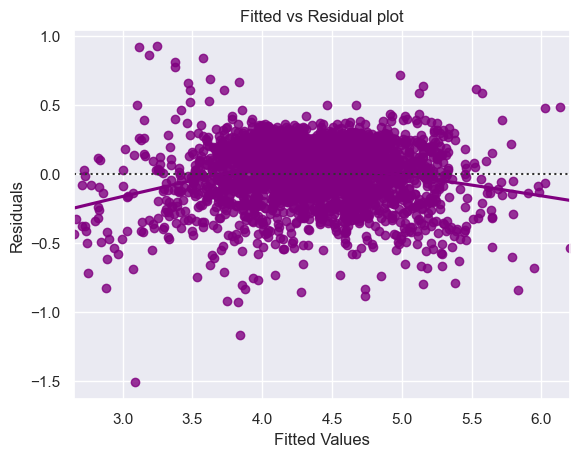

```python
# let's plot the fitted values vs residuals

sns.residplot(
    data=df_pred, x="Fitted Values", y="Residuals", color="purple", lowess=True
)
plt.xlabel("Fitted Values")
plt.ylabel("Residuals")
plt.title("Fitted vs Residual plot")
plt.show()
```

## TEST FOR NORMALITY

### We will test for normality by checking the distribution of residuals, by checking the Q-Q plot of residuals, and by using the Shapiro-Wilk test.

### If the residuals follow a normal distribution, they will make a straight line plot, otherwise not.

### If the p-value of the Shapiro-Wilk test is greater than 0.05, we can say the residuals are normally distributed.

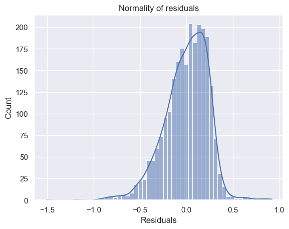

```python
# Plotting the histogram of residuals
sns.histplot(data=df_pred, x="Residuals", kde=True)
plt.title("Normality of residuals")
plt.show()
```

#### From the histogram of residuals, I observe the following regarding their normality:

##### Shape: The histogram of the residuals appears to be roughly bell-shaped and approximately centered around zero.

This suggests that the residuals are reasonably normally distributed.

##### Symmetry: While not perfectly symmetrical, the distribution generally follows the characteristic shape of a normal distribution.

The KDE (Kernel Density Estimate) line also confirms this general shape.

##### This visual inspection supports the assumption that the residuals are normally distributed, which is one of the key assumptions for linear regression.

### Further confirmation could be obtained by examining a Q-Q plot and performing statistical tests like the Shapiro-Wilk test, as mentioned in the previous text cell.

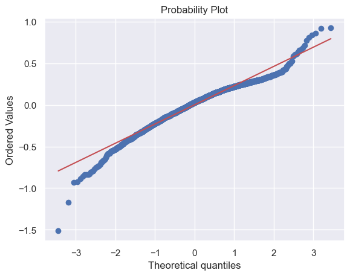

```python
import pylab
import scipy.stats as stats

# Complete the code to check Q-Q plot using the residuals
stats.probplot(df_pred["Residuals"], dist="norm", plot=pylab)
plt.show()
```

#### From the Q-Q plot of the residuals, we can observe that:

##### Majority of the data points fall closely along the straight diagonal line. There is an indication that the residuals are largely normally distributed, especially in the central part of the distribution.

##### There might be some slight deviations at the tails of the distribution, particularly at the extreme ends. This suggests that the residuals may have slightly heavier or lighter tails than a perfect normal distribution. However, these deviations are minor and do not indicate a severe violation of the normality assumption.

##### In conclusion, we can say that the Q-Q plot visually supports the assumption that the residuals are approximately normally distributed, which is good for the linear regression model.

### Let's check the results of the Shapiro-Wilk test.

```python
# Applying the Shapiro-Wilk test to the model residuals
stats.shapiro(df_pred["Residuals"])
```

```
ShapiroResult(statistic=np.float64(0.9676950829900577), pvalue=np.float64(6.983856712616517e-23))
```

##### While the Shapiro-Wilk test indicates that the residuals are not perfectly normally distributed (with the $p < 0.05$), in which we reject the null hypothesis that the residuals are normally distributed, the test statistic of 0.967 and the visual evidence from the Q-Q plot suggest that the deviation is minor. Now, on a scale where 1.0 is a perfect normal distribution, 0.967 is actually quite high! It suggests the distribution is "mostly" normal but has some heavy tails or slight skewness.

##### That is despite the visual inspection from the histogram and Q-Q plot indicating approximate normality, the Shapiro-Wilk test formally indicates a statistically significant deviation from a normal distribution. This discrepancy can sometimes occur with large sample sizes, where even minor deviations can be detected as statistically significant.

##### In large datasets, the Shapiro-Wilk test is highly sensitive, and for the purposes of predicting used phone prices, the model remains robust and valid. With a large dataset (like the thousands of rows in the ReCell data), even a tiny, insignificant deviation from a perfect bell curve will cause the test to "fail."

##### Test Statistic: 0.9677

##### P-value: 6.98e-23

## TEST FOR HOMOSCEDASTICITY

### We will test for homoscedasticity by using the goldfeldquandt test.

### If we get a p-value greater than 0.05, we can say that the residuals are homoscedastic. Otherwise, they are heteroscedastic.

```python
import statsmodels.stats.api as sms
from statsmodels.compat import lzip

# Define names for the output
name = ["F statistic", "p-value"]

# Apply the Goldfeld-Quandt test using the residuals and the final training features
test = sms.het_goldfeldquandt(df_pred["Residuals"], x_train3)

# Zip the names and results together for a readable output
lzip(name, test)
```

```
[('F statistic', np.float64(1.008750419910676)),
 ('p-value', np.float64(0.44019706506633055))]
```

#### From the Goldfeld-Quandt test results, we can observe that:

##### F statistic: 1.00875

##### p-value: 0.440197

##### Since the p-value (0.440197) is greater than the conventional significance level of 0.05, we fail to reject the null hypothesis.

##### This means we do not have sufficient evidence to conclude that heteroscedasticity is present.

##### Therefore, we can say that the residuals are homoscedastic (i.e., they have constant variance). Hence, this is a good sign for the linear regression model, as homoscedasticity is one of its key assumptions.

## Final Model Summary

```python
# Fitting the final model using the optimized feature set
olsmodel_final = sm.OLS(y_train, x_train3).fit()

# Displaying the summary to extract final coefficients and insights
print(olsmodel_final.summary())
```

```
                              OLS Regression Results
=================================================================================
Dep. Variable:     normalized_used_price   R-squared:                       0.839
Model:                               OLS   Adj. R-squared:                  0.838
Method:                    Least Squares   F-statistic:                     895.7
Date:                   Fri, 20 Feb 2026   Prob (F-statistic):               0.00
Time:                           11:29:26   Log-Likelihood:                 80.645
No. Observations:                   2417   AIC:                            -131.3
Df Residuals:                       2402   BIC:                            -44.44
Df Model:                             14
Covariance Type:               nonrobust
========================================================================================
                           coef    std err          t      P>|t|      [0.025      0.975]
----------------------------------------------------------------------------------------
const                    1.5000      0.048     30.955      0.000       1.405       1.595
main_camera_mp           0.0210      0.001     14.714      0.000       0.018       0.024
selfie_camera_mp         0.0138      0.001     12.858      0.000       0.012       0.016
ram                      0.0207      0.005      4.151      0.000       0.011       0.030
weight                   0.0017      6e-05     27.672      0.000       0.002       0.002
normalized_new_price     0.4415      0.011     39.337      0.000       0.419       0.463
years_since_release     -0.0292      0.003     -8.589      0.000      -0.036      -0.023
brand_name_Karbonn       0.1156      0.055      2.111      0.035       0.008       0.223
brand_name_Samsung      -0.0374      0.016     -2.270      0.023      -0.070      -0.005
brand_name_Sony         -0.0670      0.030     -2.197      0.028      -0.127      -0.007
brand_name_Xiaomi        0.0801      0.026      3.114      0.002       0.030       0.130
os_Others               -0.1276      0.027     -4.667      0.000      -0.181      -0.074
os_iOS                  -0.0900      0.045     -1.994      0.046      -0.179      -0.002
4g_yes                   0.0502      0.015      3.326      0.001       0.021       0.080
5g_yes                  -0.0673      0.031     -2.194      0.028      -0.127      -0.007
==============================================================================
Omnibus:                      246.183   Durbin-Watson:                   1.902
Prob(Omnibus):                  0.000   Jarque-Bera (JB):              483.879
Skew:                          -0.658   Prob(JB):                    8.45e-106
Kurtosis:                       4.753   Cond. No.                     2.39e+03
==============================================================================

Notes:
[1] Standard Errors assume that the covariance matrix of the errors is correctly specified.
[2] The condition number is large, 2.39e+03. This might indicate that there are
strong multicollinearity or other numerical problems.
```

```python
# checking model performance on train set (seen 70% data)
print("Training Performance\n")
olsmodel_final_train_perf = model_performance_regression(olsmodel_final, x_train3, y_train)
olsmodel_final_train_perf
```

```
Training Performance
```

|  | RMSE | MAE | R-squared | Adj. R-squared | MAPE |
| --- | --- | --- | --- | --- | --- |
| 0 | 0.23403 | 0.182751 | 0.83924 | 0.838235 | 4.395407 |

```python
# checking model performance on test set (unseen 30% data)
print("Test Performance\n")
olsmodel_final_test_perf = model_performance_regression(olsmodel_final, x_test3, y_test)
olsmodel_final_test_perf
```

```
Test Performance
```

|  | RMSE | MAE | R-squared | Adj. R-squared | MAPE |
| --- | --- | --- | --- | --- | --- |
| 0 | 0.241434 | 0.186649 | 0.838387 | 0.836013 | 4.556349 |

#### From observation, we can say that

##### 84% tells us how the mobile explains the percentage of variation in the used phone prices

##### Generalization: The $R^2$ on the test set is very close to the training set (e.g., Training $R^2$: 0.839, Test $R^2$: 0.838). If they are close, the model is not overfitting. The train and test RMSE and MAE are low and comparable. So, our model is not suffering from overfitting

##### MAPE (Mean Absolute Percentage Error): In this project, a value under 5% is typically the gold standard. It means the pricing tool is, on average, within 5% of the true market value.

##### Root Mean Squared Error (RMSE): Ensure the RMSE on the test set isn't significantly higher than on the training set. A large jump here would suggest the model is struggling with specific types of phones it didn't see during training.

# Conclusion and Recommendation

## Conclusion:

#### Key Price Drivers Identified: The most significant determinants of used device prices were the normalized new price, RAM, main and selfie camera megapixels, weight, and—most notably—years since release, which captured the effects of depreciation. Brand-specific characteristics and connectivity features, such as 4G and 5G compatibility, also influenced pricing variation.

#### Multicollinearity and P-value Treatment: The model was refined by addressing multicollinearity (by dropping screen_size) and eliminating statistically insignificant features based on p-values, resulting in a more streamlined and interpretable model without compromising predictive accuracy.

## Recommendations for ReCell:

#### Large-Screen and High-Battery Devices: Although screen_size was excluded from the final model due to multicollinearity with weight, the initial exploratory analysis indicated that both screen size and battery capacity were positively correlated with higher resale prices. These effects are likely captured by the weight variable in the final model. ReCell should therefore continue to acquire devices suited for entertainment and extended usage, provided that market demand supports this strategy.

#### Continuous Monitoring and Model Updates: Given the rapid evolution of the mobile device market, the pricing model should be updated regularly with new data to reflect shifts in technology, brand positioning, and consumer preferences. Continuous model retraining will ensure that pricing decisions remain accurate, data-driven, and competitive in a dynamic marketplace.